# Churn Modeling

Ryan Fabricius  
Independent Project  
5/2/2020

### Exploratory Analysis

Churn rate is defined as the proportion of a customer base to leave their service provider in a specified period of time. What if churn rate could be calculated by predicting wether each individual memeber will churn? Two business aspects come to mind when thinking about the impact of this model. Finance could use the model to increase the accuracy of their revenue forecasts, and initiatives could be made to these members to increase retainment.

```
## Classes 'spec_tbl_df', 'tbl_df', 'tbl' and 'data.frame': 9749 obs. of  14 variables:
##  $ RowNumber      : num  1 2 3 4 5 6 7 8 9 10 ...
##  $ CustomerId     : num  15634602 15647311 15619304 15701354 15737888 ...
##  $ Surname        : chr  "Hargrave" "Hill" "Onio" "Boni" ...
##  $ CreditScore    : num  619 608 502 699 850 645 822 376 501 684 ...
##  $ Geography      : chr  "France" "Spain" "France" "France" ...
##  $ Gender         : chr  "Female" "Female" "Female" "Female" ...
##  $ Age            : num  42 41 42 39 43 44 50 29 44 27 ...
##  $ Tenure         : num  2 1 8 1 2 8 7 4 4 2 ...
##  $ Balance        : num  0 83808 159661 0 125511 ...
##  $ NumOfProducts  : num  1 1 3 2 1 2 2 4 2 1 ...
##  $ HasCrCard      : num  1 0 1 0 1 1 1 1 0 1 ...
##  $ IsActiveMember : num  1 1 0 0 1 0 1 0 1 1 ...
##  $ EstimatedSalary: num  101349 112543 113932 93827 79084 ...
##  $ Exited         : num  1 0 1 0 0 1 0 1 0 0 ...
##  - attr(*, "problems")=Classes 'tbl_df', 'tbl' and 'data.frame': 1 obs. of  5 variables:
##   ..$ row     : int 9750
##   ..$ col     : chr NA
##   ..$ expected: chr "14 columns"
##   ..$ actual  : chr "12 columns"
##   ..$ file    : chr "'data/Churn_Modelling.csv'"
##  - attr(*, "spec")=
##   .. cols(
##   ..   RowNumber = col_double(),
##   ..   CustomerId = col_double(),
##   ..   Surname = col_character(),
##   ..   CreditScore = col_double(),
##   ..   Geography = col_character(),
##   ..   Gender = col_character(),
##   ..   Age = col_double(),
##   ..   Tenure = col_double(),
##   ..   Balance = col_double(),
##   ..   NumOfProducts = col_double(),
##   ..   HasCrCard = col_double(),
##   ..   IsActiveMember = col_double(),
##   ..   EstimatedSalary = col_double(),
##   ..   Exited = col_double()
##   .. )
```

Churn is represented by the “Exited” column in the dataset. Exited is a binary outcome, dummy coded as 1 if the member churned, or 0 if the memeber stayed with the bank. When dealing with binary classification, it is important to analzye the class proportions. Machine learning techniques tend to provide better results when classes are balanced.

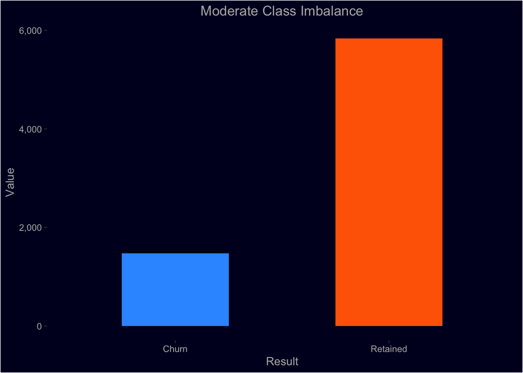

With a churn rate of approximately 20%, there is a moderate class imbalance issue. Exploring the seperation between pairs of dimensions can provide helpful insights on the data. Visually, age makes classifying easier, and there is little to no seperation when age is not involved.

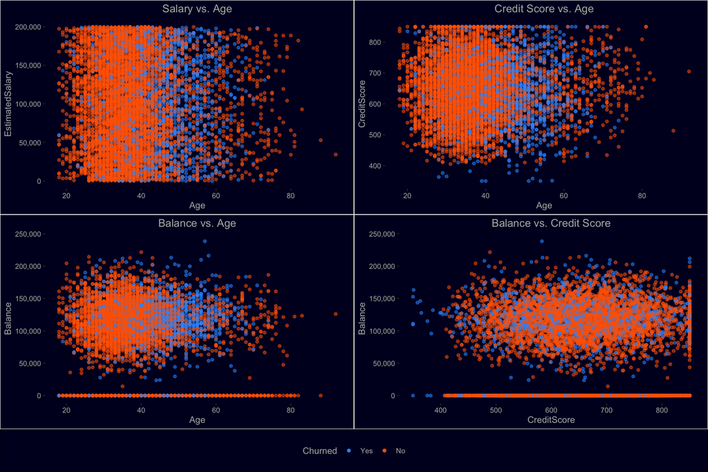

### Setting up the Models

Utlizing the themis package, class imbalance techniques used include:

- SMOTE (Synthetic Minority Over-sampling Technique)
- ROSE (Generation of syntheic data by Randomly Over Sampling Examples)
- Up-Sampling (Random minority over-sampling with replacement)
- None (control)

The themis step functions used to deal with class imbalance are the last step of each recipe.

```r
# Define the recipe for Up-Sampling
churn.recipe.up <- recipe(Exited ~ .,
                          data = head(churn.training)) %>%

  # Remove surname and rownumber
  step_rm(one_of("RowNumber", "Surname")) %>%

  # Carry non-predictors through model
  update_role(CustomerId, new_role = "Helper") %>%

  # Convert outcome to nominal
  step_num2factor(all_outcomes(),
                  levels = c("No", "Yes"),
                  transform = function(x) {x + 1}) %>%

  # Scale and Center Data
  step_normalize(all_numeric(), -has_role(match = "Helper")) %>%

  # Create dummy variables for nominal predictors
  step_dummy(all_nominal(), -all_outcomes()) %>%

  # Remove correlated and near zero predictors
  step_corr(all_numeric(), -has_role("Helper")) %>%
  step_nzv(all_predictors()) %>%

  # Deal with class imbalance
  step_upsample(Exited) # Up-Sampling step function using themis package
```

The effect of the class imbalance techniques will be analyzed using four different classification methods:

- Glmnet
- Random forest using the ranger package
- Extreme gradient boosting using XGBoost
- Support vector machines utlizing the radial basis function kernel

Each classification method will be tuned using 10-fold cross validation. Tuning was performed through the tune and dials package in the tidymodels family.

```r
# List of parsnip models

# glmnet
glmnet.mod <- logistic_reg(
      mode = "classification",
      penalty = tune(),
      mixture = tune()) %>%
  set_engine("glmnet")

# random forest
rf.mod <- rand_forest(
      mode = "classification",
      mtry = tune(),
      min_n = tune(),
      trees = tune()) %>%
  set_engine("ranger")

# xgboost model
xgb.mod <- boost_tree(
      mode = "classification",
      trees = tune(),
      mtry = tune(),
      min_n = tune(),
      learn_rate = tune(),
      loss_reduction = tune(),
      sample_size = tune()) %>%
  set_engine("xgboost")

# svm model
svm.mod <- svm_rbf(
      mode = "classification",
      cost = tune(),
      rbf_sigma = tune(),
      margin = tune()) %>%
  set_engine("kernlab")
```

```r
# Hyperparameter Grids

# glmnet
glmnet.grid <- glmnet.mod %>%
      parameters() %>%
      grid_max_entropy(size = 50)

# random forest
rf.grid <- rf.mod %>%
  parameters() %>%
  update(mtry = mtry(c(1L, 5L)),
         trees = trees(c(200L, 500L)))%>%
  grid_max_entropy(size = 50)

# xgboost
xgb.grid <- xgb.mod %>%
  parameters() %>%
  update(mtry = mtry(c(1L, 5L)),
         trees = trees(c(200L, 500L))) %>%
  grid_max_entropy(size = 50)

# svm
svm.grid <- svm.mod %>%
  parameters() %>%
  grid_max_entropy(size = 50)
```

### Evaluating Tuned Models

Models were evaluated using the AUC (Area Under the ROC Curve). Accuracy is misleading when classes are imbalanced. A method of always classifying a member as “not churning” would lead you to 80% accuracy.

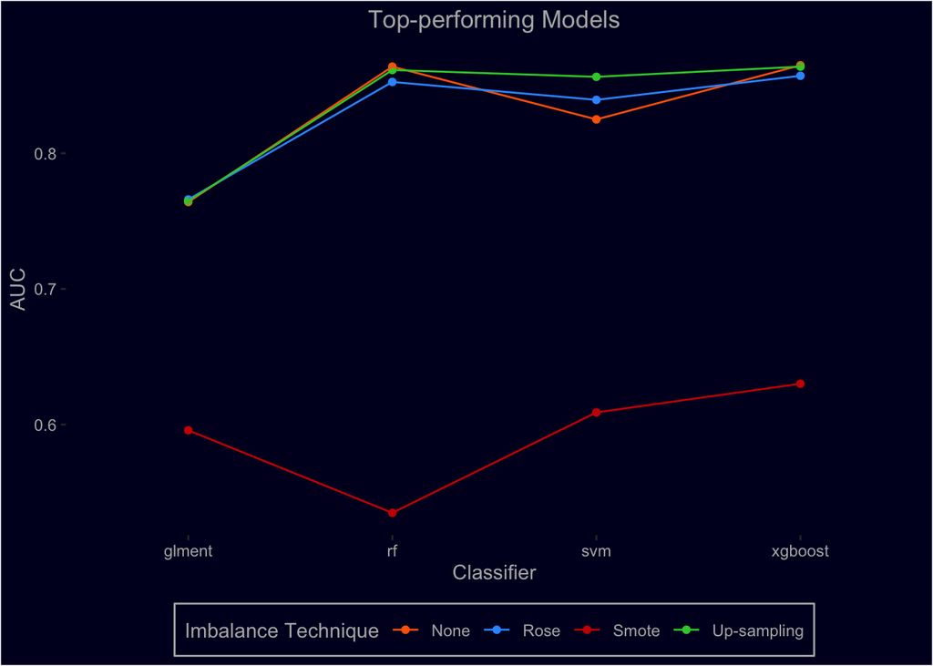

XGBoost had the highest AUC by a narrow margin. Other than SMOTE, the class imbalance technqiues used do not show much variation from each other. Ultimately, up-sampling was chosen from the remaining three, as it was the simplest technique that also dealt with the class imbalance issue.